# Stone walls do a prison make: law on the landscape | Queensland Historical Atlas

[figure not shown]

# Stone walls do a prison make: law on the landscape

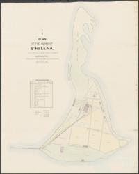

Plan of the island of St Helena, HM Penal Establishment, Queensland, 1887

By:

Chris Dawson

The imposition of a new and dominant system of law was an important part of the European settlement of Queensland. Imprisonment was the main form of punishment under this system, and prisons became tangible artefacts of the spread of these new laws across the colony. Prison walls created strict divisions in the landscape, separating the free world on the outside from the unfree world on the inside, where people were redefined as ‘prisoners’ and became the property of the state, subject to a strictly regulated regime.

**A new form of punishment**

The use of long-term imprisonment as punishment was a relatively new idea in the early nineteenth century, and was unknown within Aboriginal cultures, where exile and physical punishment were among the legal sanctions. To be locked in prison became a defacto form of exile for Aborigines, as it restricted them from conducting vital cultural practices in their own country. This contributed to their suffering inside prisons, and Aboriginal deaths in custody were an issue from the earliest days of colonisation. In 1853 a Brisbane judge commented on the conditions in Sydney’s Cockatoo Island prison:

‘It was a painful consideration that the punishment at Cockatoo was felt ten times more severely by the blacks than by the whites, and most of them die. Recently, one who had sentence of death commuted, and was sent there, suffered most acutely, and died in seven weeks. But there appeared no alternative, for if they were sent to the gaol here, or to the Newcastle breakwater, they would very probably escape.’ (*Moreton Bay Free Press*, 29 November 1853)

**Civic pride and fear**

The presence and quality of a prison reflected the status of towns in the young colony. During the 1840s-50s, Brisbane and Ipswich competed to become the preeminent population centre in the north of the colony, and civic authorities lobbied to have a new prison built in their own town. The local preeminence of Brisbane was indicated in 1846 when the New South Wales government decided to convert a former convict building on Queen Street into a prison. However, only £820 was allocated to construct the prison, as compared to the £13,000 that had been spent on Sydney’s Darlinghurst Gaol in 1841. In the same week that the new Brisbane prison opened, it was described in the *Moreton Bay Courier* on 5 January 1850 as being ‘not sufficiently secure’ due to careless workmanship. The decaying porphyry-block structure was repeatedly criticised throughout the 1850s as being too small, rickety, and out-of-date with new penological trends. Plans for a new gaol were delayed by the ongoing uncertainty over Separation, with the New South Wales government unwilling to spend freely in what might soon be a separate colony.

The first public building to open in Brisbane following Separation was the prison on Petrie Terrace, built at a cost of £26,000 and subject to proud boasts in local newspapers. The new prisons that opened around the colony during the next decade indicated the growing importance of certain towns, although there were times when local residents opposed prisons in those towns. A group of prominent Toowoomba citizens, for example, petitioned against the presence of a predominately female prison in 1870, as reported in *Queensland Votes and Proceedings*, arguing that when ‘women of ill-fame’ were released they would ‘resort to crimes of the most flagitious and demoralizing character’.

**Nineteenth century Queensland prisons**

| **Location** | **Opened** | **Closed** |
| --- | --- | --- |
| Queen Street, Brisbane | 1849 | 1860 |
| Petrie Terrace, Brisbane | 1860 | 1883 |
| Boggo Road, Woolloongabba, Brisbane | 1883 | 2000 |
| *Proserpine* (prison hulk), Fort Lytton | 1864 | 1867 |
| St Helena Island Penal Establishment, Moreton Bay | 1865 | 1931 |
| Rockhampton | 1864 | - |
| Toowoomba | 1864 | 1903 |
| Roma | 1872 | 1903 |
| Townsville/Stewart Creek | 1878 | - |
| Croydon | 1888 | 1892 |
| Thursday Island | 1891 | 1983 |
| Blackall | 1891 | 1902 |
| Mackay | 1893 | 1935 |
| Cooktown | 1893 | 1921 |
| Normanton | 1893 | 1945 |
| Cairns | 1897 | 1925 |

**The growing network**

The spread of European settlement throughout colonial Queensland was mirrored by the expanding prison system. While there was only one prison in the colony at the time of Separation in 1859, ten years later there were four. By the 1890s there were prisons as far north as Thursday Island and Normanton. The growth of the sugar and mining industries played a role in this expansion, and decline in those industries resulted in the closure or downgrading of some prisons.

**Nineteenth century police gaols**

The prison network was supported by police gaols, which were small, police-managed facilities, larger than the usual lockups attached to police stations, and holding short-term prisoners serving two weeks or less. Police gaols could be upgraded to official prisons (or prisons downgraded to police gaols) according to local requirements and population fluctuations. The remote gaol at Camooweal, for example, was opened specifically to restrict the movement of unlicensed Chinese miners into Queensland from the west, but a few years later, following the decline of the mining industry and the introduction of immigration restrictions, the now-empty gaol was deemed surplus to requirements and was closed.

**Nineteenth century police gaols**

| **Location** | **Opened** |
| --- | --- |
| Fortitude Valley, Brisbane | 1863 |
| Thursday Island | 1877 |
| Blackall | 1881 |
| Mackay | 1883 |
| Cooktown | c1884 |
| Ingham | 1886 |
| Ayr | 1887 |
| Charters Towers | 1888 |
| Croydon | 1888 |
| Normanton | 1891 |
| Tambo | 1893 |
| Herberton | 1897 |
| Camooweal | 1897 |

**State Farms**